# df

Autogenerated data summary from dataMaid

2023-11-27 18:52:34

# Data report overview

The dataset examined has the following dimensions:

| Feature | Result |
| --- | --- |
| Number of observations | 192 |
| Number of variables | 58 |

### Checks performed

The following variable checks were performed, depending on the data type of each variable:

|  | character | factor | labelled | haven labelled | numeric | integer | logical | Date |
| --- | --- | --- | --- | --- | --- | --- | --- | --- |
| Identify miscoded missing values | × | × | × | × | × | × |  | × |
| Identify prefixed and suffixed whitespace | × | × | × | × |  |  |  |  |
| Identify levels with < 6 obs. | × | × | × | × |  |  |  |  |
| Identify case issues | × | × | × | × |  |  |  |  |
| Identify misclassified numeric or integer variables | × | × | × | × |  |  |  |  |
| Identify outliers |  |  |  |  | × | × |  | × |

Please note that all numerical values in the following have been rounded to 2 decimals.

# Summary table

|  | Variable class | # unique values | Missing observations | Any problems? |
| --- | --- | --- | --- | --- |
| [STUDY ID #] | numeric | 192 | 0.00 % |  |
| Type | numeric | 2 | 0.00 % |  |
| Gender | numeric | 2 | 0.00 % |  |
| Height | numeric | 49 | 0.00 % |  |
| Weight | numeric | 144 | 0.00 % |  |
| Age | numeric | 48 | 0.00 % | × |
| BMI | numeric | 188 | 0.00 % |  |
| COPD | numeric | 2 | 0.00 % |  |
| alpha1-Antitrypsin Deficiency | numeric | 2 | 0.00 % |  |
| Cystic Fibrosis | numeric | 2 | 0.00 % |  |
| Idiopathic Pulmonary Hypertension | numeric | 2 | 0.00 % |  |
| Interstitial Lung Disease | numeric | 2 | 0.00 % |  |
| Pulm_Other | numeric | 2 | 0.00 % |  |
| First Lung Transplant | numeric | 2 | 0.00 % |  |
| Redo Lung Transplant | numeric | 2 | 0.00 % |  |
| ExVIVO Lung Perfusion | numeric | 2 | 0.00 % |  |
| Preoperative ECLS | numeric | 2 | 0.00 % |  |
| LAS score | numeric | 63 | 6.25 % | × |
| Pre_Hb | numeric | 73 | 0.00 % | × |
| Pre_Hct | numeric | 96 | 0.00 % | × |
| Pre_Platelets | numeric | 135 | 0.00 % | × |
| Pre_PT | numeric | 86 | 0.00 % | × |
| Pre_INR | numeric | 50 | 0.00 % | × |
| Pre_PTT | numeric | 131 | 0.52 % | × |
| Pre_Fibrinogen | numeric | 6 | 97.40 % | × |
| Pre_Creatinine | numeric | 69 | 0.00 % | × |
| Intraoperative ECLS | numeric | 1 | 0.00 % | × |
| ECLS_ECMO | numeric | 2 | 0.00 % |  |
| ECLS_CPB | numeric | 2 | 0.00 % | × |
| Intra_Fresh Frozen Plasma | numeric | 9 | 0.00 % | × |
| Intra_Packed Cells | numeric | 14 | 0.00 % | × |
| Intra_Platelets | numeric | 9 | 0.00 % | × |
| Intra_Cryoprecipitate | numeric | 6 | 0.00 % | × |
| Duration of ICU Stay (days) | numeric | 34 | 0.52 % | × |
| DEATH_DATE | character | 33 | 83.33 % | × |
| ALIVE_30DAYS_YN | character | 2 | 0.00 % | × |
| ALIVE_90DAYS_YN | character | 2 | 0.00 % |  |
| ALIVE_12MTHS_YN | character | 2 | 0.00 % |  |
| ICU_LOS | numeric | 178 | 0.00 % | × |
| HOSPITAL_LOS | numeric | 173 | 0.00 % | × |
| RBC 0-24hrs | numeric | 8 | 68.75 % | × |
| RBC 24-48hrs | numeric | 6 | 72.92 % | × |
| RBC 48-72hrs | numeric | 5 | 75.00 % | × |
| RBC 72hr Total | numeric | 10 | 0.00 % |  |
| FFP 0-24hrs | numeric | 7 | 80.21 % | × |
| FFP 24-48hrs | numeric | 3 | 82.81 % | × |
| FFP 48-72hrs | numeric | 3 | 82.81 % | × |
| FFP 72hr Total | numeric | 6 | 0.00 % | × |
| Plt 0-24hrs | numeric | 6 | 80.21 % | × |
| Plt 24-48hrs | numeric | 5 | 81.25 % | × |
| Plt 48-72hrs | numeric | 4 | 82.29 % | × |
| Plt 72hr Total | numeric | 6 | 0.00 % | × |
| Cryo 0-24hrs | numeric | 3 | 80.73 % |  |
| Cryo 24-48hrs | numeric | 3 | 82.81 % | × |
| Cryo 48-72hrs | numeric | 3 | 82.81 % | × |
| Cryo 72hr Total | numeric | 3 | 0.00 % | × |
| Total 24hr RBC | numeric | 17 | 0.00 % | × |
| Massive Transfusion | numeric | 2 | 0.00 % |  |

# Variable list

## STUDY ID

| Feature | Result |
| --- | --- |
| Variable type | numeric |
| Number of missing obs. | 0 (0 %) |
| Number of unique values | 192 |
| Median | 101.5 |
| 1st and 3rd quartiles | 53.75; 149.25 |
| Min. and max. | 1; 197 |

[figure not shown]

## Type

- Note that this variable is treated as a factor variable below, as it only takes a few unique values.

| Feature | Result |
| --- | --- |
| Variable type | numeric |
| Number of missing obs. | 0 (0 %) |
| Number of unique values | 2 |
| Mode | “0” |
| Reference category | 0 |

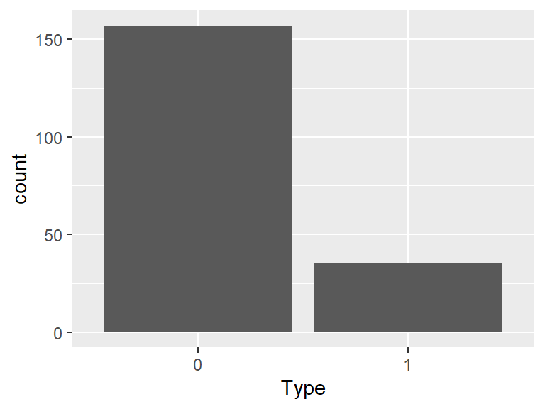

## Gender

- Note that this variable is treated as a factor variable below, as it only takes a few unique values.

| Feature | Result |
| --- | --- |
| Variable type | numeric |
| Number of missing obs. | 0 (0 %) |
| Number of unique values | 2 |
| Mode | “1” |
| Reference category | 0 |

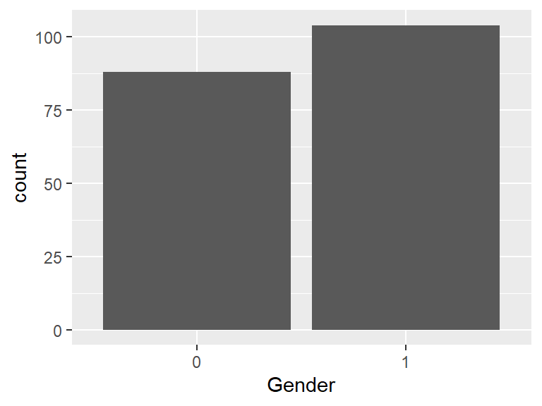

## Height

| Feature | Result |
| --- | --- |
| Variable type | numeric |
| Number of missing obs. | 0 (0 %) |
| Number of unique values | 49 |
| Median | 167 |
| 1st and 3rd quartiles | 158; 174 |
| Min. and max. | 140; 192 |

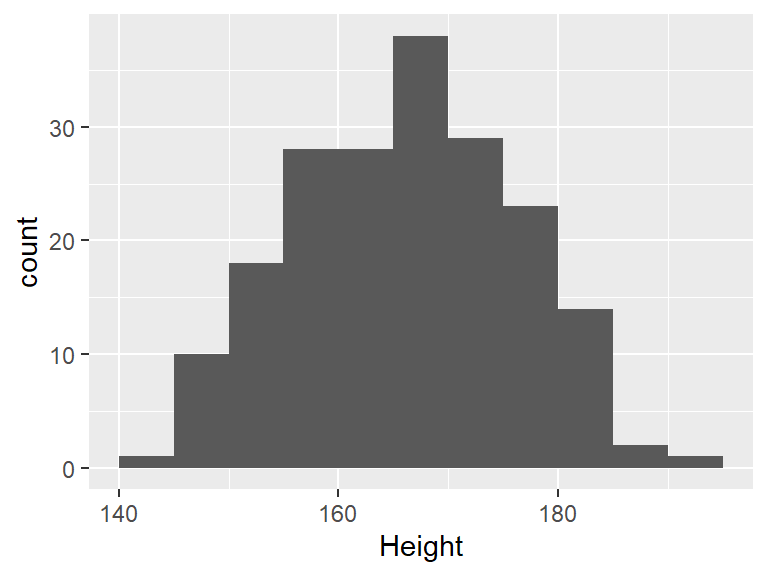

## Weight

| Feature | Result |
| --- | --- |
| Variable type | numeric |
| Number of missing obs. | 0 (0 %) |
| Number of unique values | 144 |
| Median | 67.1 |
| 1st and 3rd quartiles | 55.88; 78 |
| Min. and max. | 33.1; 107.8 |

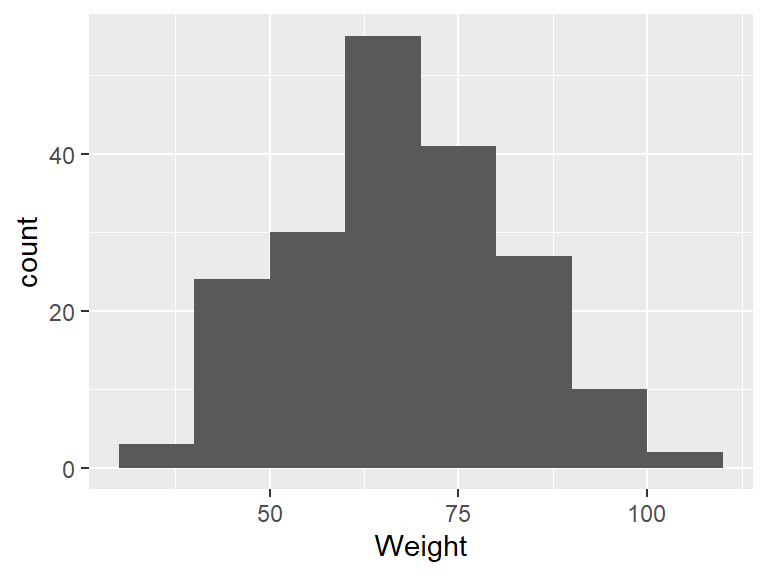

## Age

| Feature | Result |
| --- | --- |
| Variable type | numeric |
| Number of missing obs. | 0 (0 %) |
| Number of unique values | 48 |
| Median | 61 |
| 1st and 3rd quartiles | 48; 68 |
| Min. and max. | 19; 76 |

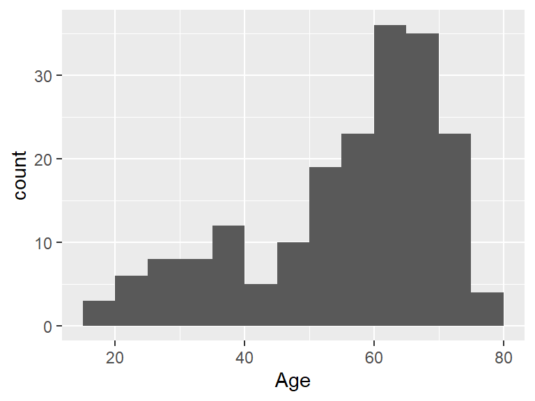

- Note that the following possible outlier values were detected: "76".

## BMI

| Feature | Result |
| --- | --- |
| Variable type | numeric |
| Number of missing obs. | 0 (0 %) |
| Number of unique values | 188 |
| Median | 24.37 |
| 1st and 3rd quartiles | 20.62; 27.42 |
| Min. and max. | 15.54; 31.78 |

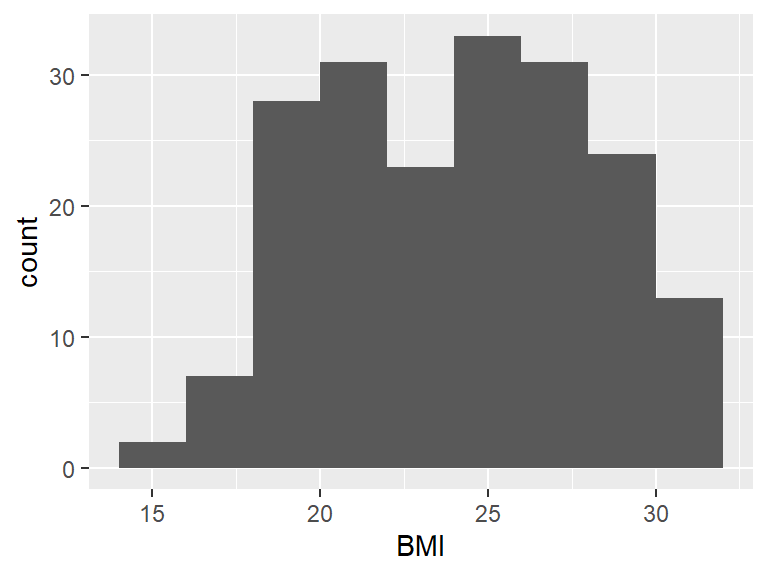

## COPD

- Note that this variable is treated as a factor variable below, as it only takes a few unique values.

| Feature | Result |
| --- | --- |
| Variable type | numeric |
| Number of missing obs. | 0 (0 %) |
| Number of unique values | 2 |
| Mode | “0” |
| Reference category | 0 |

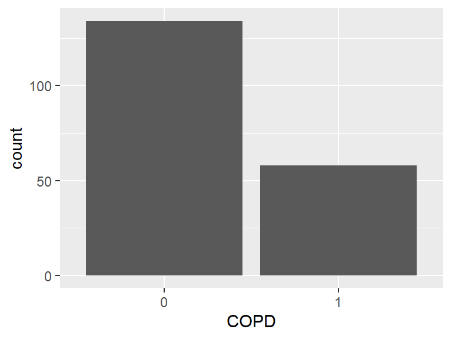

## alpha1-Antitrypsin Deficiency

- Note that this variable is treated as a factor variable below, as it only takes a few unique values.

| Feature | Result |
| --- | --- |
| Variable type | numeric |
| Number of missing obs. | 0 (0 %) |
| Number of unique values | 2 |
| Mode | “0” |
| Reference category | 0 |

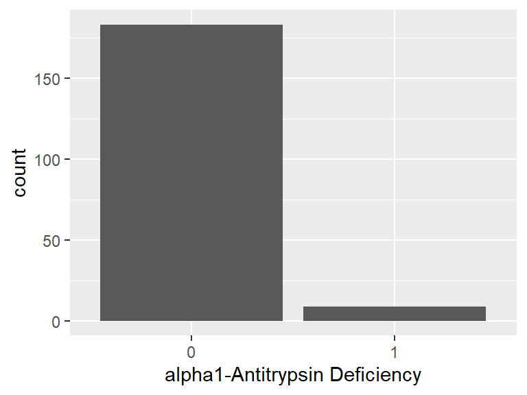

## Cystic Fibrosis

- Note that this variable is treated as a factor variable below, as it only takes a few unique values.

| Feature | Result |
| --- | --- |
| Variable type | numeric |
| Number of missing obs. | 0 (0 %) |
| Number of unique values | 2 |
| Mode | “0” |
| Reference category | 0 |

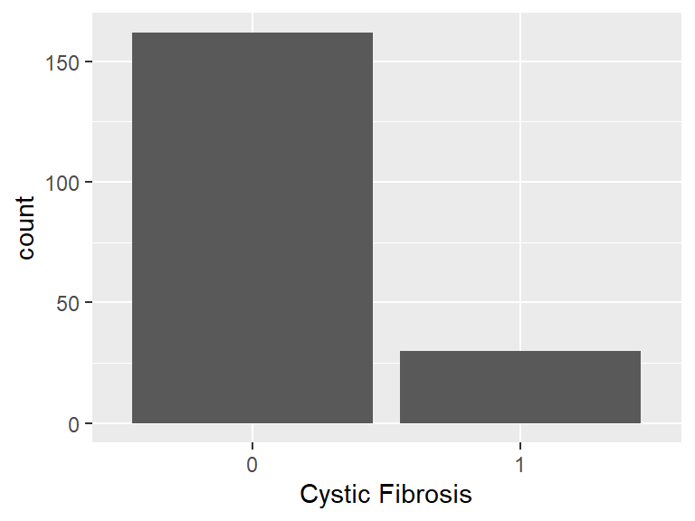

## Idiopathic Pulmonary Hypertension

- Note that this variable is treated as a factor variable below, as it only takes a few unique values.

| Feature | Result |
| --- | --- |
| Variable type | numeric |
| Number of missing obs. | 0 (0 %) |
| Number of unique values | 2 |
| Mode | “0” |
| Reference category | 0 |

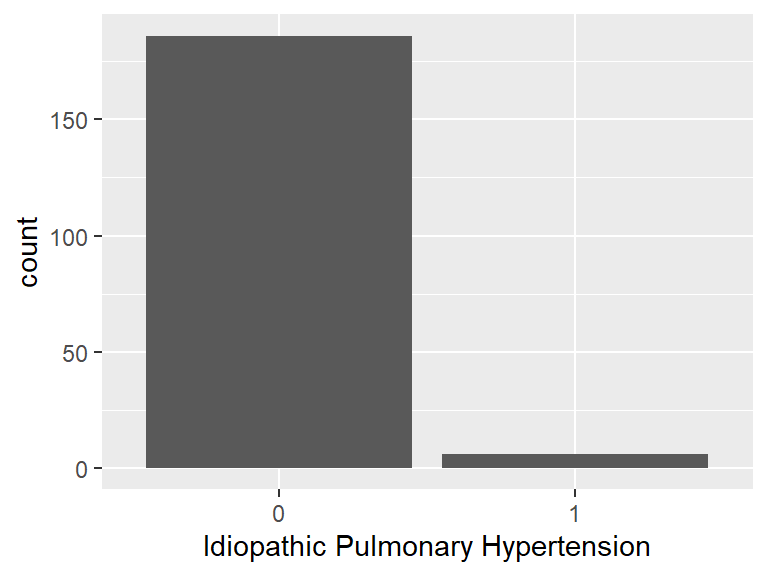

## Interstitial Lung Disease

- Note that this variable is treated as a factor variable below, as it only takes a few unique values.

| Feature | Result |
| --- | --- |
| Variable type | numeric |
| Number of missing obs. | 0 (0 %) |
| Number of unique values | 2 |
| Mode | “0” |
| Reference category | 0 |

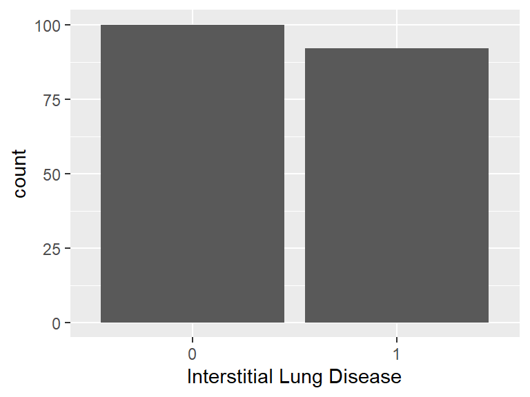

## Pulm_Other

- Note that this variable is treated as a factor variable below, as it only takes a few unique values.

| Feature | Result |
| --- | --- |
| Variable type | numeric |
| Number of missing obs. | 0 (0 %) |
| Number of unique values | 2 |
| Mode | “0” |
| Reference category | 0 |

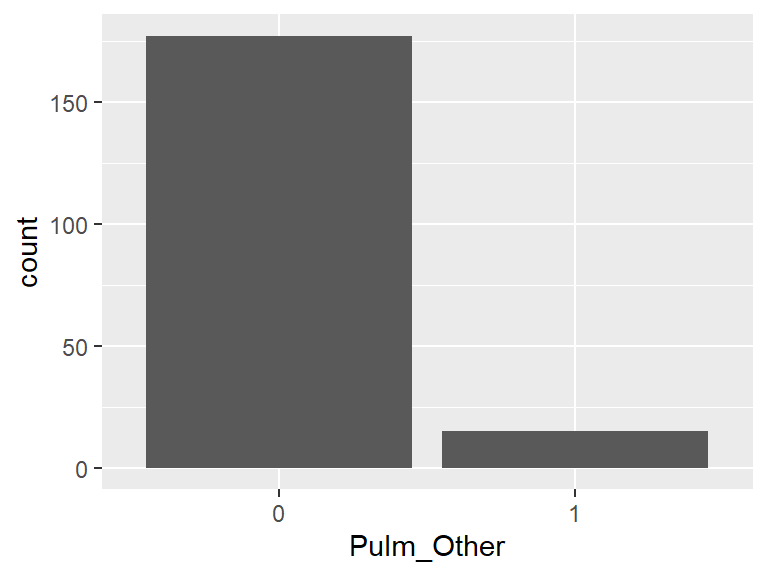

## First Lung Transplant

- Note that this variable is treated as a factor variable below, as it only takes a few unique values.

| Feature | Result |
| --- | --- |
| Variable type | numeric |
| Number of missing obs. | 0 (0 %) |
| Number of unique values | 2 |
| Mode | “1” |
| Reference category | 0 |

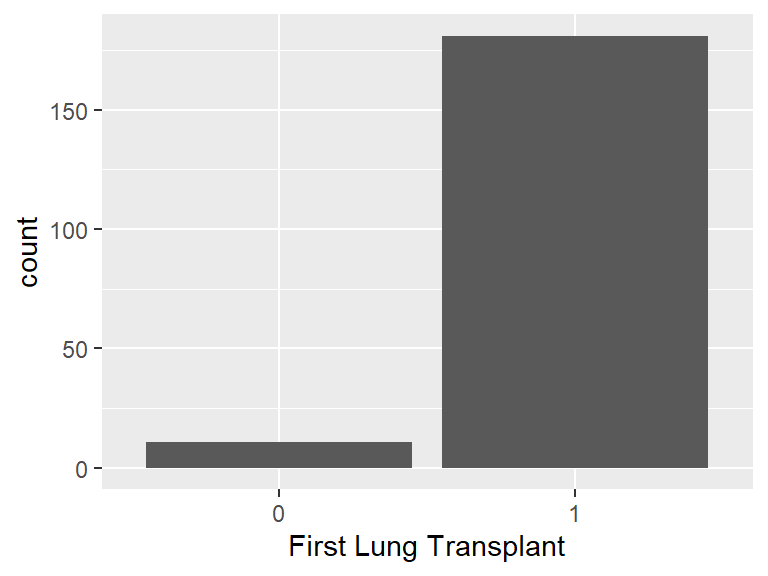

## Redo Lung Transplant

- Note that this variable is treated as a factor variable below, as it only takes a few unique values.

| Feature | Result |
| --- | --- |
| Variable type | numeric |
| Number of missing obs. | 0 (0 %) |
| Number of unique values | 2 |
| Mode | “0” |
| Reference category | 0 |

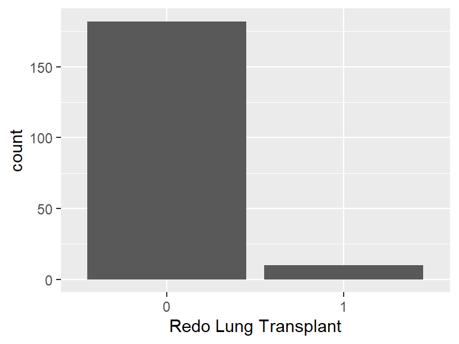

## ExVIVO Lung Perfusion

- Note that this variable is treated as a factor variable below, as it only takes a few unique values.

| Feature | Result |
| --- | --- |
| Variable type | numeric |
| Number of missing obs. | 0 (0 %) |
| Number of unique values | 2 |
| Mode | “0” |
| Reference category | 0 |

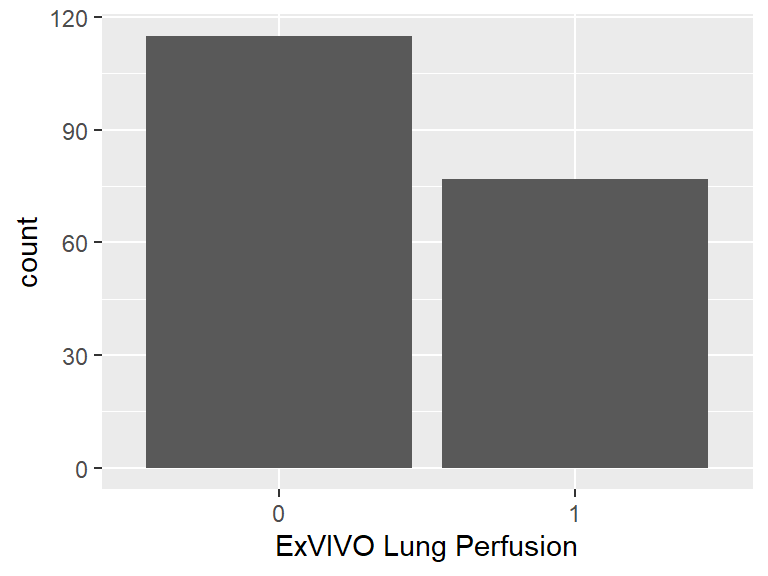

## Preoperative ECLS

- Note that this variable is treated as a factor variable below, as it only takes a few unique values.

| Feature | Result |
| --- | --- |
| Variable type | numeric |
| Number of missing obs. | 0 (0 %) |
| Number of unique values | 2 |
| Mode | “0” |
| Reference category | 0 |

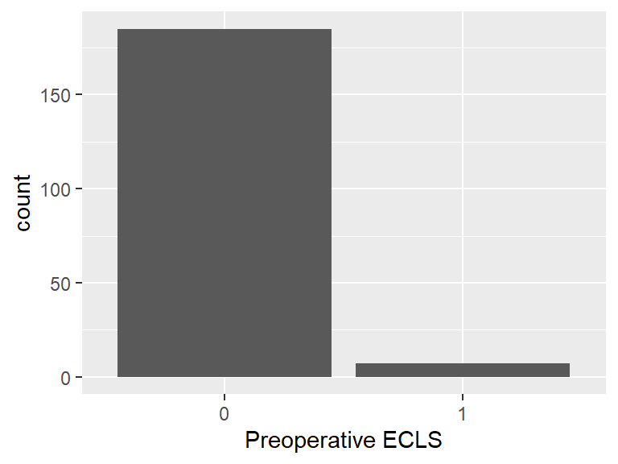

## LAS score

| Feature | Result |
| --- | --- |
| Variable type | numeric |
| Number of missing obs. | 12 (6.25 %) |
| Number of unique values | 62 |
| Median | 34 |
| 1st and 3rd quartiles | 32.38; 38 |
| Min. and max. | 24; 90 |

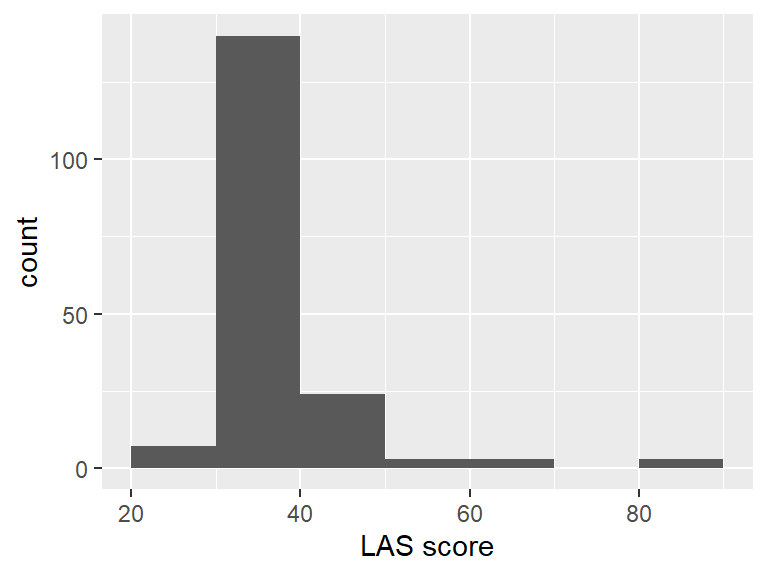

- Note that the following possible outlier values were detected: "24", "28", "30", "30.8", "31", "87", "88", "90".

## Pre_Hb

| Feature | Result |
| --- | --- |
| Variable type | numeric |
| Number of missing obs. | 0 (0 %) |
| Number of unique values | 73 |
| Median | 131 |
| 1st and 3rd quartiles | 117; 142 |
| Min. and max. | 73; 168 |

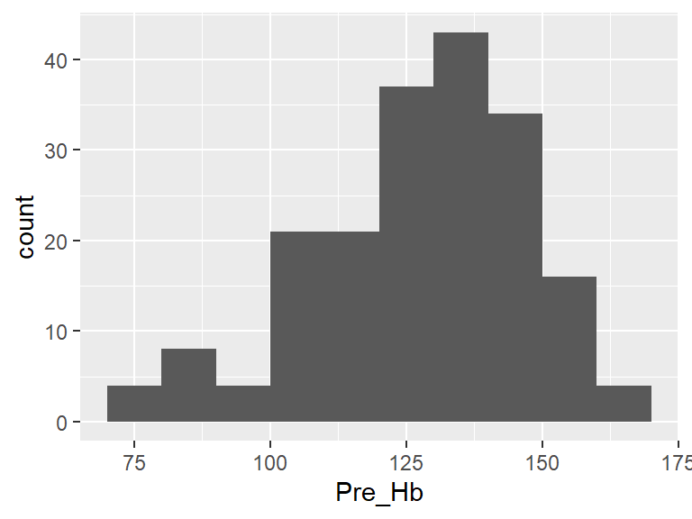

- Note that the following possible outlier values were detected: "164", "168".

## Pre_Hct

| Feature | Result |
| --- | --- |
| Variable type | numeric |
| Number of missing obs. | 0 (0 %) |
| Number of unique values | 96 |
| Median | 0.4 |
| 1st and 3rd quartiles | 0.37; 0.43 |
| Min. and max. | 0.22; 0.51 |

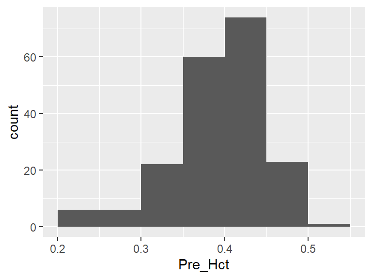

- Note that the following possible outlier values were detected: "0.22", "0.22", "0.24", "0.5", "0.51".

## Pre_Platelets

| Feature | Result |
| --- | --- |
| Variable type | numeric |
| Number of missing obs. | 0 (0 %) |
| Number of unique values | 135 |
| Median | 243.5 |
| 1st and 3rd quartiles | 202.5; 301.25 |
| Min. and max. | 89; 882 |

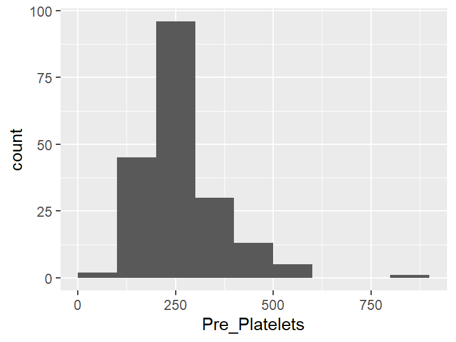

- Note that the following possible outlier values were detected: "89", "93", "113", "119", "122", …, "130", "132", "134", "136", "882" (2 values omitted).

## Pre_PT

| Feature | Result |
| --- | --- |
| Variable type | numeric |
| Number of missing obs. | 0 (0 %) |
| Number of unique values | 86 |
| Median | 11.6 |
| 1st and 3rd quartiles | 11.07; 12.5 |
| Min. and max. | 9.6; 37.4 |

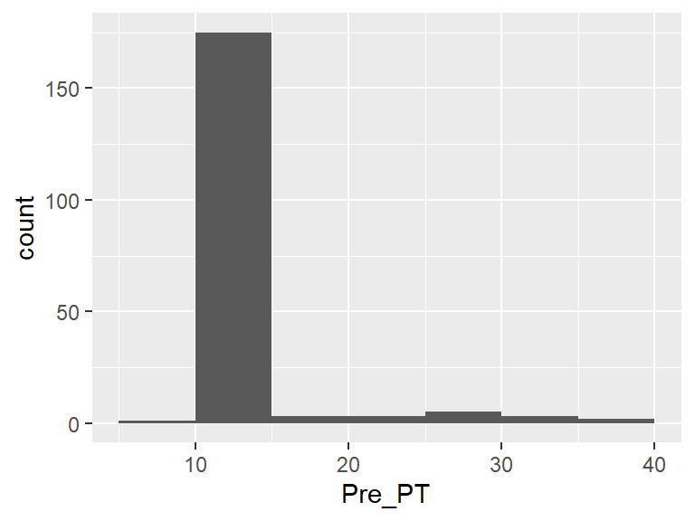

- Note that the following possible outlier values were detected: "9.6", "10.1", "10.2", "10.3", "10.4", …, "30.2", "32.8", "34.3", "36.4", "37.4" (9 values omitted).

## Pre_INR

| Feature | Result |
| --- | --- |
| Variable type | numeric |
| Number of missing obs. | 0 (0 %) |
| Number of unique values | 50 |
| Median | 1 |
| 1st and 3rd quartiles | 0.9; 1.1 |
| Min. and max. | 0.8; 3.7 |

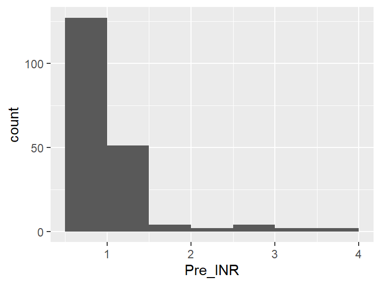

- Note that the following possible outlier values were detected: "1.5", "1.6", "1.8", "1.9", "2", …, "2.8", "3.1", "3.2", "3.56", "3.7" (4 values omitted).

## Pre_PTT

| Feature | Result |
| --- | --- |
| Variable type | numeric |
| Number of missing obs. | 1 (0.52 %) |
| Number of unique values | 130 |
| Median | 24.5 |
| 1st and 3rd quartiles | 22.2; 26.75 |
| Min. and max. | 17.7; 93.5 |

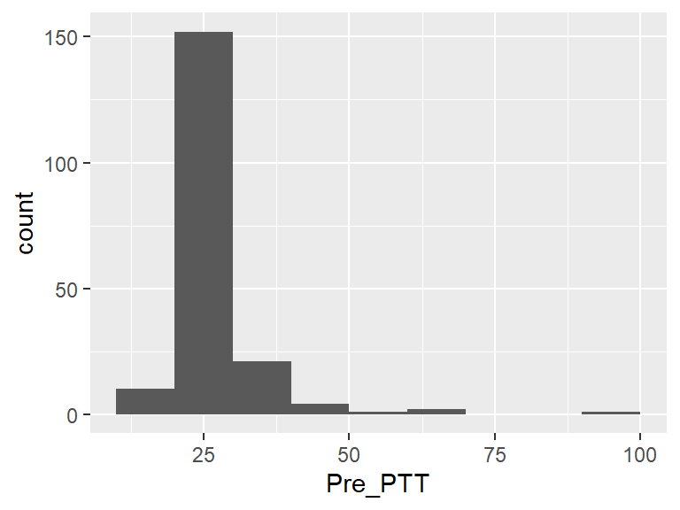

- Note that the following possible outlier values were detected: "17.7", "39.7", "42.7", "42.9", "45.7", "46.9", "50.9", "61.3", "64.2", "93.5".

## Pre_Fibrinogen

- Note that this variable is treated as a factor variable below, as it only takes a few unique values.

| Feature | Result |
| --- | --- |
| Variable type | numeric |
| Number of missing obs. | 187 (97.4 %) |
| Number of unique values | 5 |
| Mode | “1.29999995231628” |
| Reference category | 1.29999995231628 |

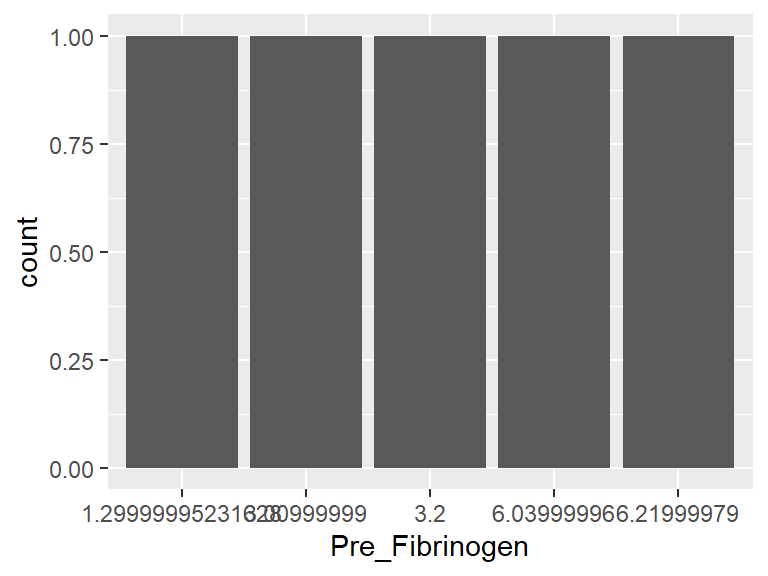

- Note that the following levels have at most five observations: "1.29999995231628", "3.00999999", "3.2", "6.03999996", "6.21999979".

## Pre_Creatinine

| Feature | Result |
| --- | --- |
| Variable type | numeric |
| Number of missing obs. | 0 (0 %) |
| Number of unique values | 69 |
| Median | 69 |
| 1st and 3rd quartiles | 62.75; 84 |
| Min. and max. | 37; 169 |

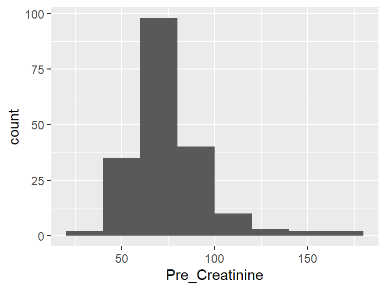

- Note that the following possible outlier values were detected: "37", "38", "42", "47", "48", "50", "51", "52", "53", "54".

## Intraoperative ECLS

- The variable only takes one (non-missing) value: "0". The variable contains 0 % missing observations.

## ECLS_ECMO

- Note that this variable is treated as a factor variable below, as it only takes a few unique values.

| Feature | Result |
| --- | --- |
| Variable type | numeric |
| Number of missing obs. | 0 (0 %) |
| Number of unique values | 2 |
| Mode | “1” |
| Reference category | 0 |

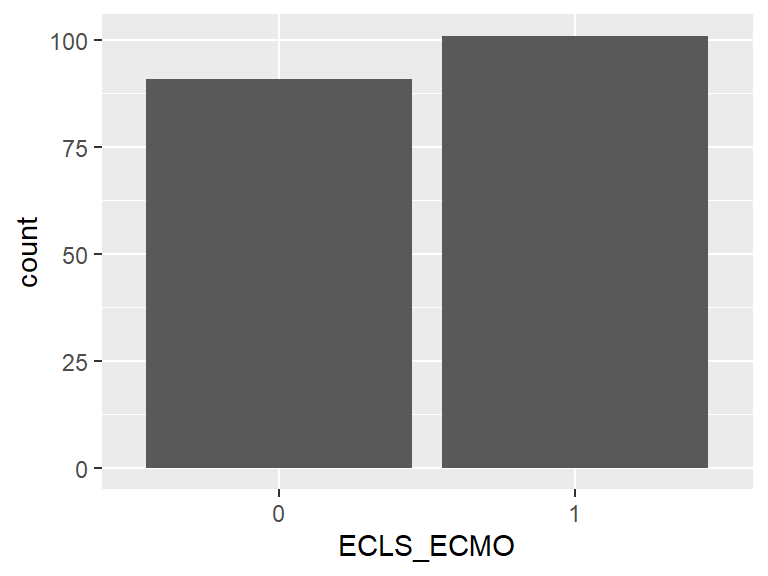

## ECLS_CPB

- Note that this variable is treated as a factor variable below, as it only takes a few unique values.

| Feature | Result |
| --- | --- |
| Variable type | numeric |
| Number of missing obs. | 0 (0 %) |
| Number of unique values | 2 |
| Mode | “0” |
| Reference category | 0 |

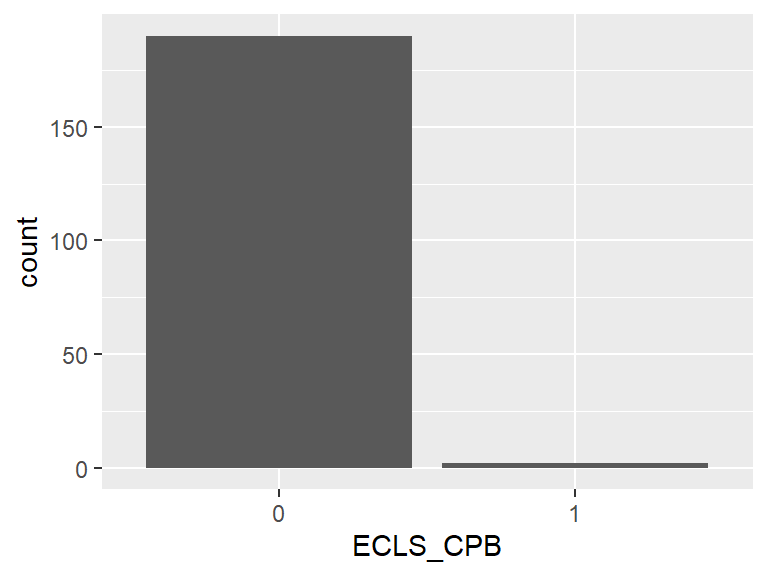

- Note that the following levels have at most five observations: "1".

## Intra_Fresh Frozen Plasma

| Feature | Result |
| --- | --- |
| Variable type | numeric |
| Number of missing obs. | 0 (0 %) |
| Number of unique values | 9 |
| Median | 0 |
| 1st and 3rd quartiles | 0; 0 |
| Min. and max. | 0; 26 |

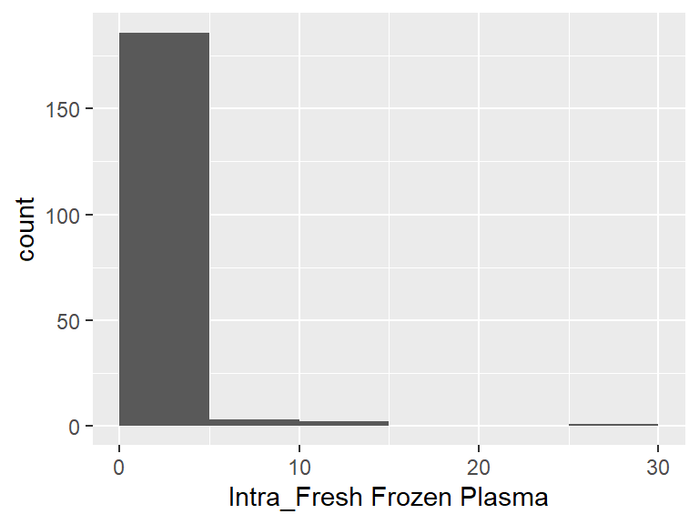

- Note that the following possible outlier values were detected: "2", "4", "6", "8", "10", "11", "13", "26".

## Intra_Packed Cells

| Feature | Result |
| --- | --- |
| Variable type | numeric |
| Number of missing obs. | 0 (0 %) |
| Number of unique values | 14 |
| Median | 1 |
| 1st and 3rd quartiles | 0; 3 |
| Min. and max. | 0; 36 |

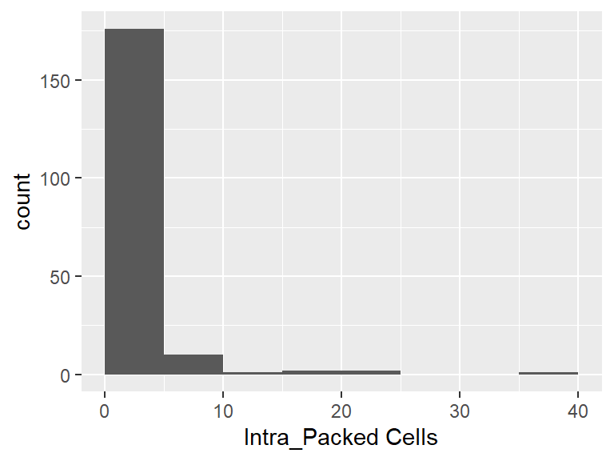

- Note that the following possible outlier values were detected: "36".

## Intra_Platelets

| Feature | Result |
| --- | --- |
| Variable type | numeric |
| Number of missing obs. | 0 (0 %) |
| Number of unique values | 9 |
| Median | 0 |
| 1st and 3rd quartiles | 0; 0 |
| Min. and max. | 0; 11 |

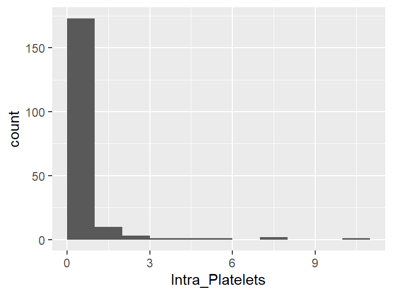

- Note that the following possible outlier values were detected: "1", "2", "3", "4", "5", "6", "8", "11".

## Intra_Cryoprecipitate

| Feature | Result |
| --- | --- |
| Variable type | numeric |
| Number of missing obs. | 0 (0 %) |
| Number of unique values | 6 |
| Median | 0 |
| 1st and 3rd quartiles | 0; 0 |
| Min. and max. | 0; 50 |

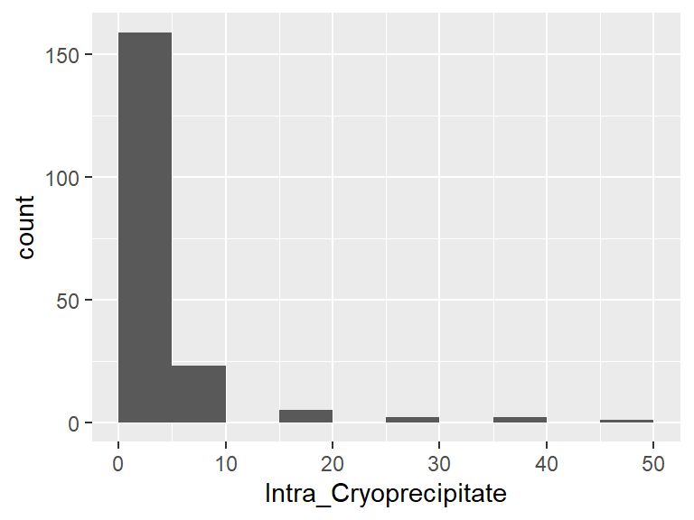

- Note that the following possible outlier values were detected: "10", "20", "30", "40", "50".

## Duration of ICU Stay (days)

| Feature | Result |
| --- | --- |
| Variable type | numeric |
| Number of missing obs. | 1 (0.52 %) |
| Number of unique values | 33 |
| Median | 4 |
| 1st and 3rd quartiles | 2; 8 |
| Min. and max. | 1; 99 |

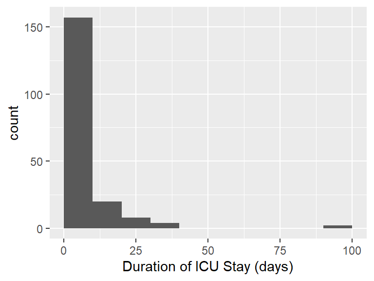

- The following suspected missing value codes enter as regular values: "99".
- Note that the following possible outlier values were detected: "91", "99".

## DEATH_DATE

| Feature | Result |
| --- | --- |
| Variable type | character |
| Number of missing obs. | 160 (83.33 %) |
| Number of unique values | 32 |
| Mode | “02-DEC-2018” |

[figure not shown]

- Note that the following levels have at most five observations: "02-DEC-2018", "02-JUN-2019", "03-MAR-2019", "04-NOV-2018", "05-MAR-2019", …, "29-JUN-2019", "30-APR-2019", "30-MAY-2019", "30-SEP-2019", "31-JAN-2019" (22 values omitted).

## ALIVE_30DAYS_YN

| Feature | Result |
| --- | --- |
| Variable type | character |
| Number of missing obs. | 0 (0 %) |
| Number of unique values | 2 |
| Mode | “Y” |

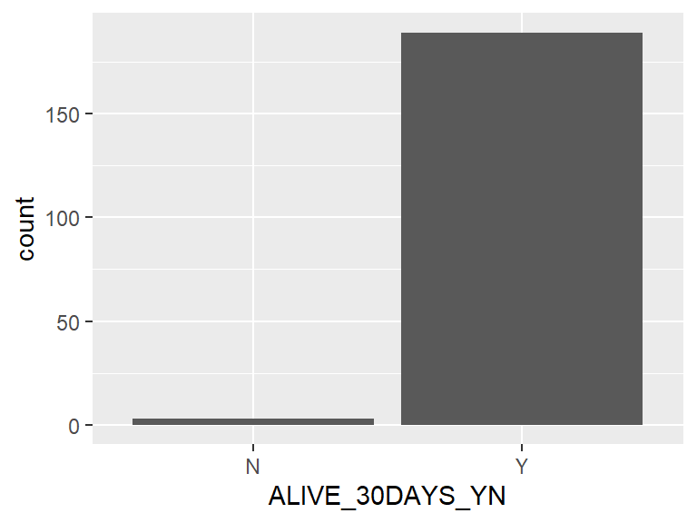

- Note that the following levels have at most five observations: "N".

## ALIVE_90DAYS_YN

| Feature | Result |
| --- | --- |
| Variable type | character |
| Number of missing obs. | 0 (0 %) |
| Number of unique values | 2 |
| Mode | “Y” |

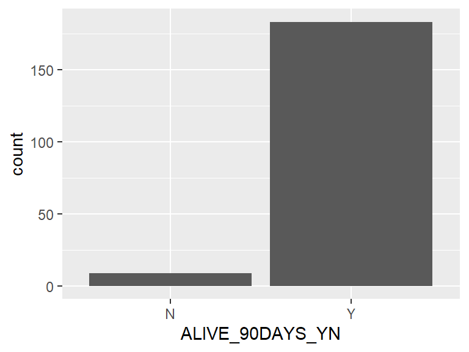

## ALIVE_12MTHS_YN

| Feature | Result |
| --- | --- |
| Variable type | character |
| Number of missing obs. | 0 (0 %) |
| Number of unique values | 2 |
| Mode | “Y” |

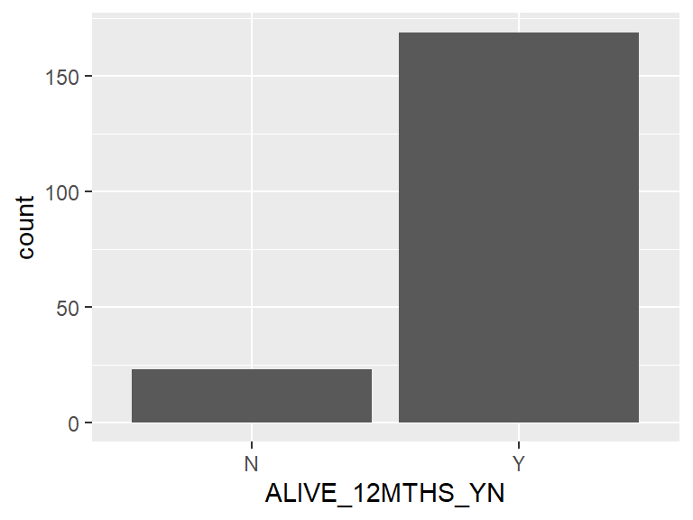

## ICU_LOS

| Feature | Result |
| --- | --- |
| Variable type | numeric |
| Number of missing obs. | 0 (0 %) |
| Number of unique values | 178 |
| Median | 3.62 |
| 1st and 3rd quartiles | 2.12; 7.78 |
| Min. and max. | 0.63; 380.86 |

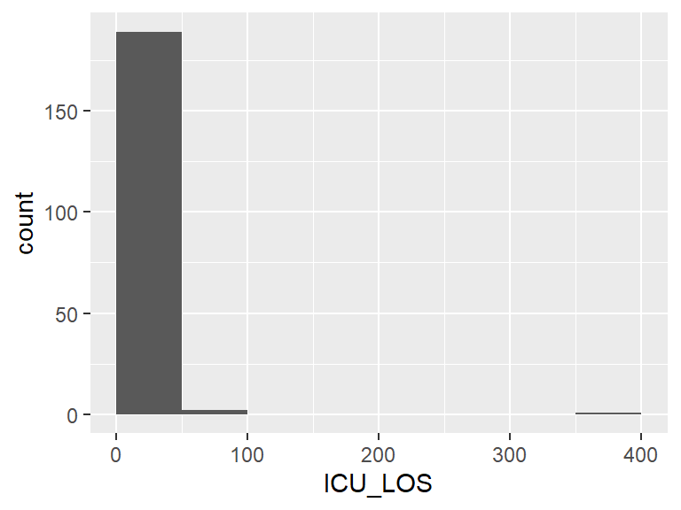

- Note that the following possible outlier values were detected: "0.63", "0.95", "1.03", "1.05", "1.07", …, "1.21", "1.22", "90.54", "98.7", "380.86" (4 values omitted).

## HOSPITAL_LOS

| Feature | Result |
| --- | --- |
| Variable type | numeric |
| Number of missing obs. | 0 (0 %) |
| Number of unique values | 173 |
| Median | 22.84 |
| 1st and 3rd quartiles | 15.68; 36.06 |
| Min. and max. | 9.66; 381.52 |

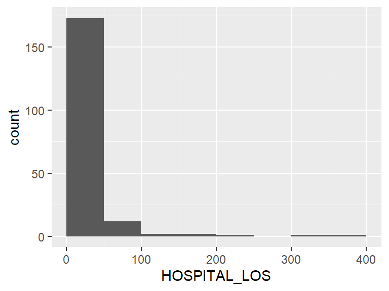

- Note that the following possible outlier values were detected: "131", "134.71", "160.95", "177.73", "216.57", "317.06", "381.52".

## RBC 0-24hrs

| Feature | Result |
| --- | --- |
| Variable type | numeric |
| Number of missing obs. | 132 (68.75 %) |
| Number of unique values | 7 |
| Median | 1 |
| 1st and 3rd quartiles | 0; 1 |
| Min. and max. | 0; 9 |

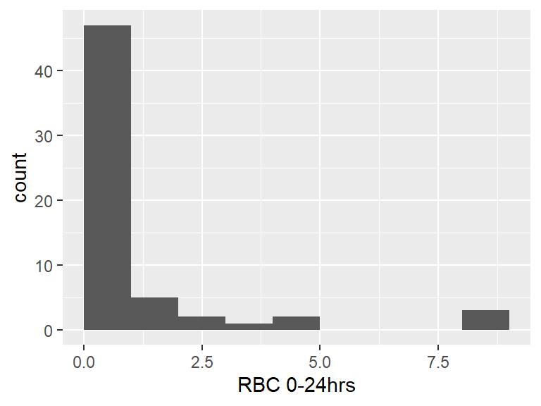

- The following suspected missing value codes enter as regular values: "9".
- Note that the following possible outlier values were detected: "3", "4", "5", "9".

## RBC 24-48hrs

- Note that this variable is treated as a factor variable below, as it only takes a few unique values.

| Feature | Result |
| --- | --- |
| Variable type | numeric |
| Number of missing obs. | 140 (72.92 %) |
| Number of unique values | 5 |
| Mode | “0” |
| Reference category | 0 |

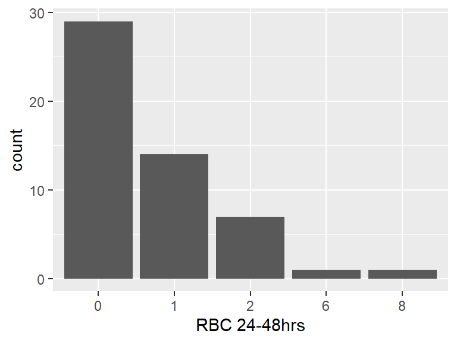

- The following suspected missing value codes enter as regular values: "8".
- Note that the following levels have at most five observations: "6", "8".

## RBC 48-72hrs

- Note that this variable is treated as a factor variable below, as it only takes a few unique values.

| Feature | Result |
| --- | --- |
| Variable type | numeric |
| Number of missing obs. | 144 (75 %) |
| Number of unique values | 4 |
| Mode | “0” |
| Reference category | 0 |

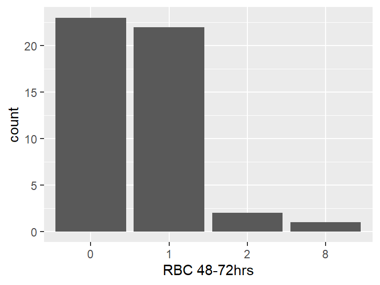

- The following suspected missing value codes enter as regular values: "8".
- Note that the following levels have at most five observations: "2", "8".

## RBC 72hr Total

| Feature | Result |
| --- | --- |
| Variable type | numeric |
| Number of missing obs. | 0 (0 %) |
| Number of unique values | 10 |
| Median | 0 |
| 1st and 3rd quartiles | 0; 1 |
| Min. and max. | 0; 23 |

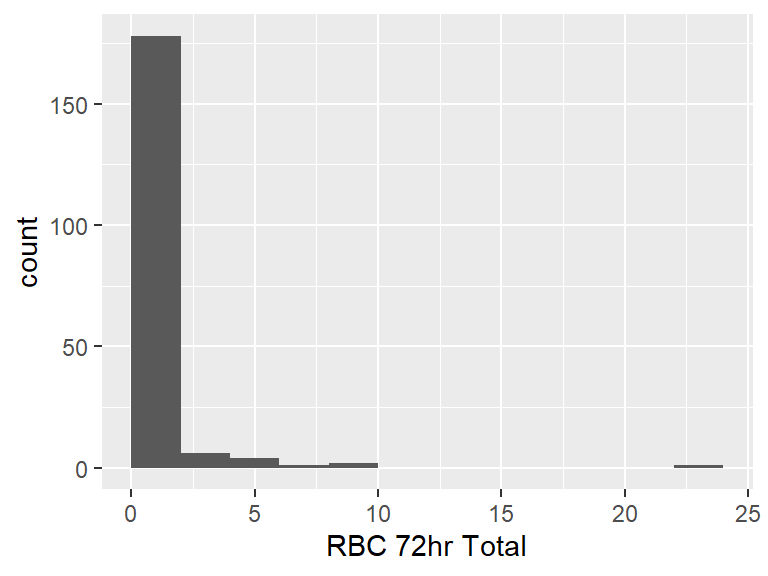

## FFP 0-24hrs

| Feature | Result |
| --- | --- |
| Variable type | numeric |
| Number of missing obs. | 154 (80.21 %) |
| Number of unique values | 6 |
| Median | 0 |
| 1st and 3rd quartiles | 0; 0 |
| Min. and max. | 0; 7 |

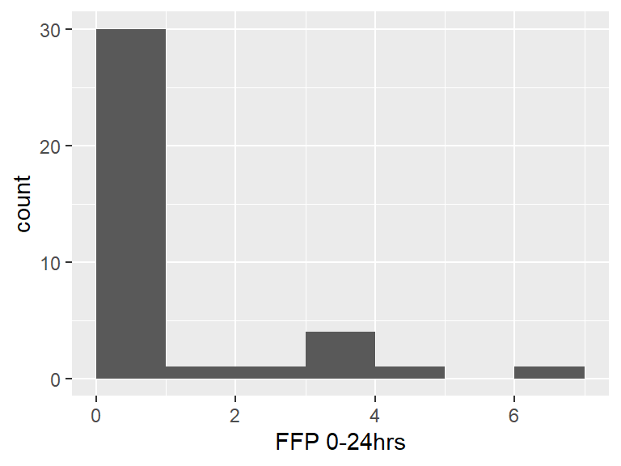

- Note that the following possible outlier values were detected: "2", "3", "4", "5", "7".

## FFP 24-48hrs

- Note that this variable is treated as a factor variable below, as it only takes a few unique values.

| Feature | Result |
| --- | --- |
| Variable type | numeric |
| Number of missing obs. | 159 (82.81 %) |
| Number of unique values | 2 |
| Mode | “0” |
| Reference category | 0 |

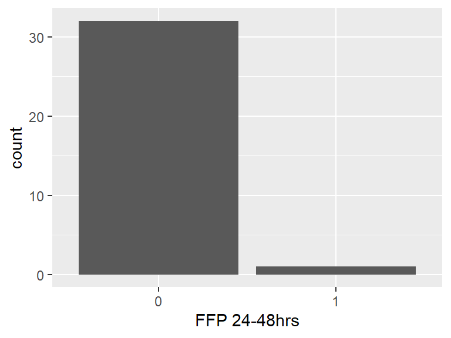

- Note that the following levels have at most five observations: "1".

## FFP 48-72hrs

- Note that this variable is treated as a factor variable below, as it only takes a few unique values.

| Feature | Result |
| --- | --- |
| Variable type | numeric |
| Number of missing obs. | 159 (82.81 %) |
| Number of unique values | 2 |
| Mode | “0” |
| Reference category | 0 |

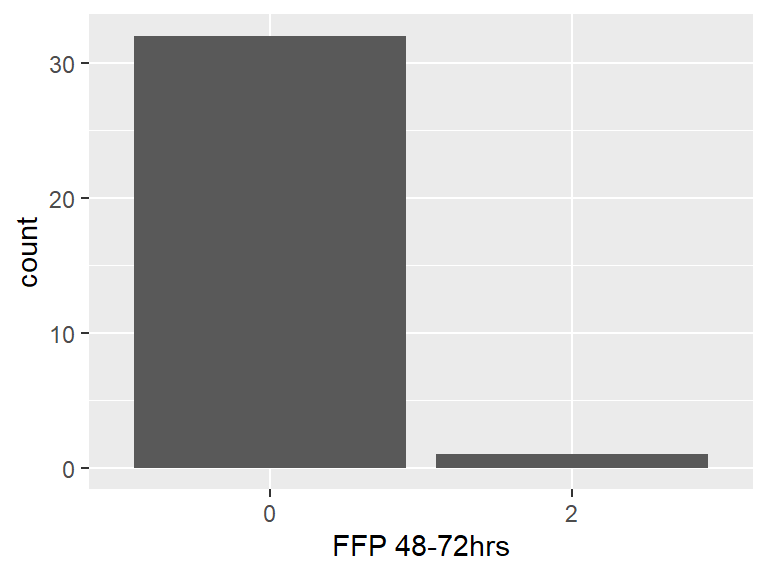

- Note that the following levels have at most five observations: "2".

## FFP 72hr Total

| Feature | Result |
| --- | --- |
| Variable type | numeric |
| Number of missing obs. | 0 (0 %) |
| Number of unique values | 6 |
| Median | 0 |
| 1st and 3rd quartiles | 0; 0 |
| Min. and max. | 0; 8 |

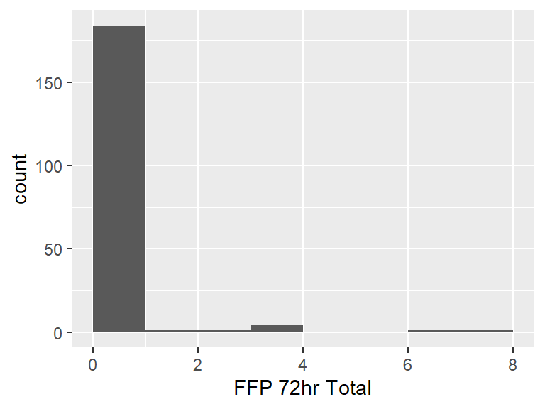

- Note that the following possible outlier values were detected: "2", "3", "4", "7", "8".

## Plt 0-24hrs

- Note that this variable is treated as a factor variable below, as it only takes a few unique values.

| Feature | Result |
| --- | --- |
| Variable type | numeric |
| Number of missing obs. | 154 (80.21 %) |
| Number of unique values | 5 |
| Mode | “0” |
| Reference category | 0 |

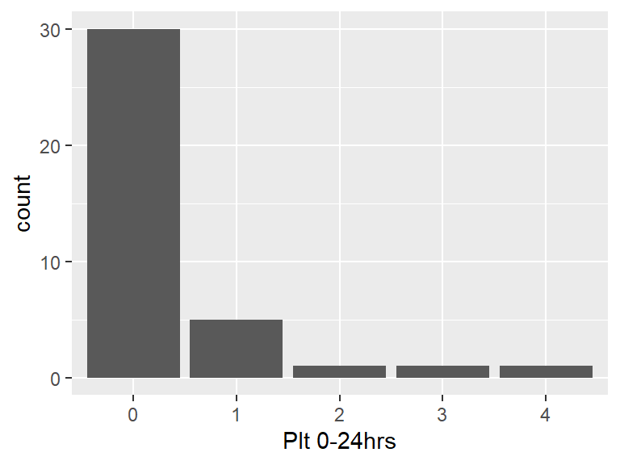

- Note that the following levels have at most five observations: "1", "2", "3", "4".

## Plt 24-48hrs

- Note that this variable is treated as a factor variable below, as it only takes a few unique values.

| Feature | Result |
| --- | --- |
| Variable type | numeric |
| Number of missing obs. | 156 (81.25 %) |
| Number of unique values | 4 |
| Mode | “0” |
| Reference category | 0 |

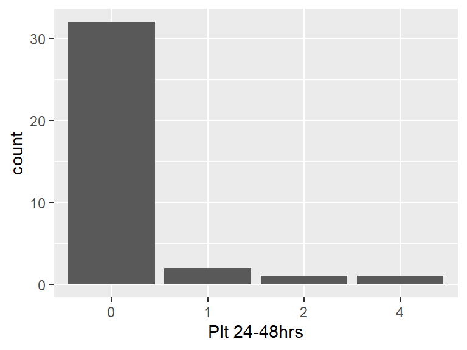

- Note that the following levels have at most five observations: "1", "2", "4".

## Plt 48-72hrs

- Note that this variable is treated as a factor variable below, as it only takes a few unique values.

| Feature | Result |
| --- | --- |
| Variable type | numeric |
| Number of missing obs. | 158 (82.29 %) |
| Number of unique values | 3 |
| Mode | “0” |
| Reference category | 0 |

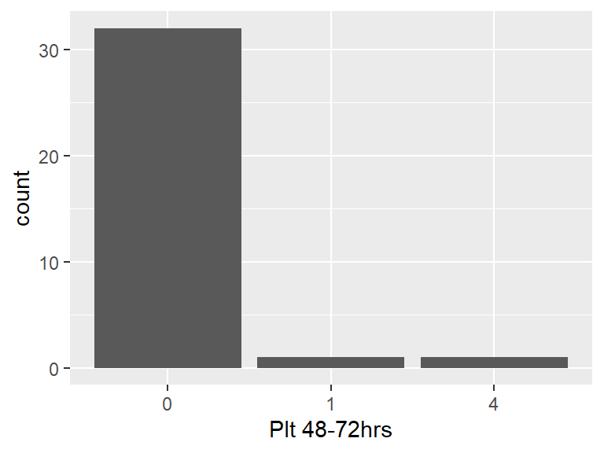

- Note that the following levels have at most five observations: "1", "4".

## Plt 72hr Total

| Feature | Result |
| --- | --- |
| Variable type | numeric |
| Number of missing obs. | 0 (0 %) |
| Number of unique values | 6 |
| Median | 0 |
| 1st and 3rd quartiles | 0; 0 |
| Min. and max. | 0; 10 |

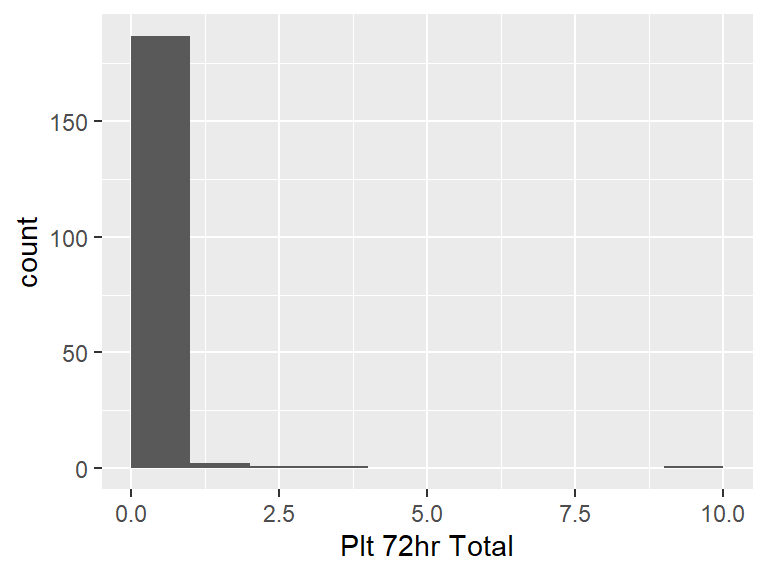

- Note that the following possible outlier values were detected: "1", "2", "3", "4", "10".

## Cryo 0-24hrs

- Note that this variable is treated as a factor variable below, as it only takes a few unique values.

| Feature | Result |
| --- | --- |
| Variable type | numeric |
| Number of missing obs. | 155 (80.73 %) |
| Number of unique values | 2 |
| Mode | “0” |
| Reference category | 0 |

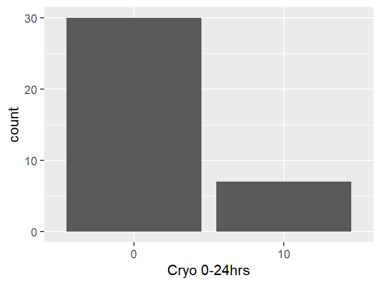

## Cryo 24-48hrs

- Note that this variable is treated as a factor variable below, as it only takes a few unique values.

| Feature | Result |
| --- | --- |
| Variable type | numeric |
| Number of missing obs. | 159 (82.81 %) |
| Number of unique values | 2 |
| Mode | “0” |
| Reference category | 0 |

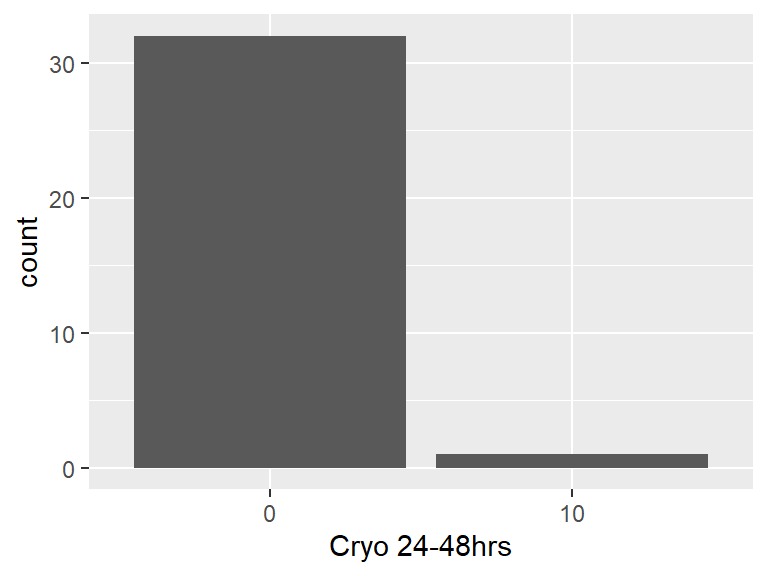

- Note that the following levels have at most five observations: "10".

## Cryo 48-72hrs

- Note that this variable is treated as a factor variable below, as it only takes a few unique values.

| Feature | Result |
| --- | --- |
| Variable type | numeric |
| Number of missing obs. | 159 (82.81 %) |
| Number of unique values | 2 |
| Mode | “0” |
| Reference category | 0 |

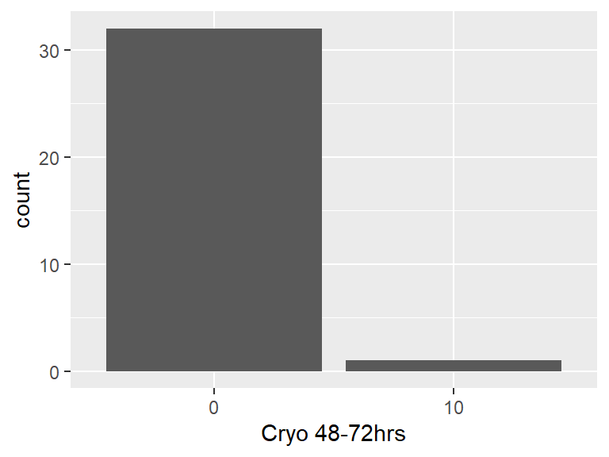

- Note that the following levels have at most five observations: "10".

## Cryo 72hr Total

- Note that this variable is treated as a factor variable below, as it only takes a few unique values.

| Feature | Result |
| --- | --- |
| Variable type | numeric |
| Number of missing obs. | 0 (0 %) |
| Number of unique values | 3 |
| Mode | “0” |
| Reference category | 0 |

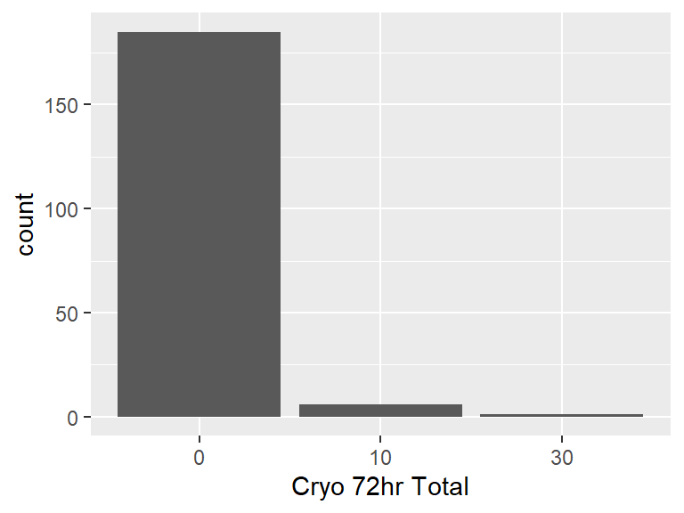

- Note that the following levels have at most five observations: "30".

## Total 24hr RBC

| Feature | Result |
| --- | --- |
| Variable type | numeric |
| Number of missing obs. | 0 (0 %) |
| Number of unique values | 17 |
| Median | 1 |
| 1st and 3rd quartiles | 0; 4 |
| Min. and max. | 0; 38 |

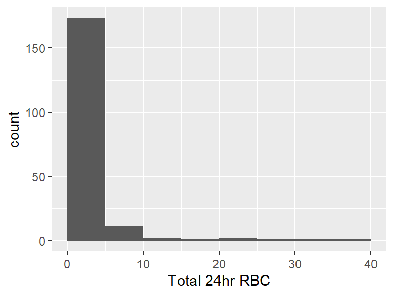

- Note that the following possible outlier values were detected: "31", "38".

## Massive Transfusion

- Note that this variable is treated as a factor variable below, as it only takes a few unique values.

| Feature | Result |
| --- | --- |
| Variable type | numeric |
| Number of missing obs. | 0 (0 %) |
| Number of unique values | 2 |
| Mode | “0” |
| Reference category | 0 |

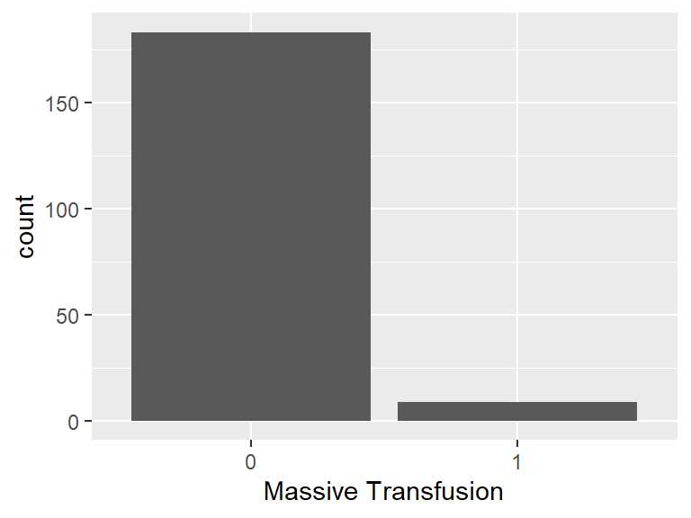

Report generation information:

- Created by: RamizK01 (username: `ramiz`).
- Report creation time: Mon Nov 27 2023 18:52:36
- Report was run from directory: `C:/Users/ramiz/OneDrive - University of Toronto/0 Data Science in Health II/DS-IN-HEALTH-2-FINAL`
- dataMaid v1.4.1 [Pkg: 2021-10-08 from CRAN (R 4.2.3)]
- R version 4.2.1 (2022-06-23 ucrt).
- Platform: x86_64-w64-mingw32/x64 (64-bit)(Windows 10 x64 (build 22621)).
- Function call: `makeDataReport(data = df, output = "html", replace = TRUE)`